# PMTCT cohort report

# Report details

Reporting date range: **01 Jan 2009 - 31 Dec 2009**  
Date and time report generated: **17 December 2020, 21:29 UTC**  
Reporting package versions:  
**genericreportr**: 0.0.1.1  
**idreportr**: 0.0.3.9001

Comments or questions to: **his@oca.msf.org**

[output not shown]

Data for **01 Jan 2009 - 31 Dec 2009:**

| Reporting period summary | Figure |
| --- | --- |
| Number of admissions | 439 |
| Number of deliveries | 395 |
| Number of EID results received | 77 |
| Number of programme discharges | 216 |

# Reporting period

The data presented in this section refers only to the user-defined period: **01 Jan 2009 - 31 Dec 2009**. Cohorts of women who were admitted or delivered during this period are presented separately. Reference is made to cohorts from the 12 months prior to **31 December 2009** and the full programme to allow quick comparisons.

## Admissions

### Table

|  | Previous 13 months up to 31 December 2009 N (%) | Previous 13 months up to 31 December 2009 Total |
| --- | --- | --- |
| Month: |  | 480 |
| Dec-09 | 47 (9.8%) |  |
| Nov-09 | 44 (9.2%) |  |
| Oct-09 | 29 (6.0%) |  |
| Sep-09 | 34 (7.1%) |  |
| Aug-09 | 33 (6.9%) |  |
| Jul-09 | 32 (6.7%) |  |
| Jun-09 | 33 (6.9%) |  |
| May-09 | 40 (8.3%) |  |
| Apr-09 | 37 (7.7%) |  |
| Mar-09 | 50 (10.4%) |  |
| Feb-09 | 30 (6.2%) |  |
| Jan-09 | 30 (6.2%) |  |
| Dec-08 | 41 (8.5%) |  |

|  | Full programme inclusion up to 31 December 2009 N (%) | Full programme inclusion up to 31 December 2009 Total |
| --- | --- | --- |
| Month: |  | 948 |
| Dec | 137 (14.5%) |  |
| Nov | 119 (12.6%) |  |
| Oct | 66 (7.0%) |  |
| Sep | 69 (7.3%) |  |
| Aug | 73 (7.7%) |  |
| Jul | 68 (7.2%) |  |
| Jun | 62 (6.5%) |  |
| May | 67 (7.1%) |  |
| Apr | 78 (8.2%) |  |
| Mar | 84 (8.9%) |  |
| Feb | 63 (6.6%) |  |
| Jan | 62 (6.5%) |  |

### Monthly admissions

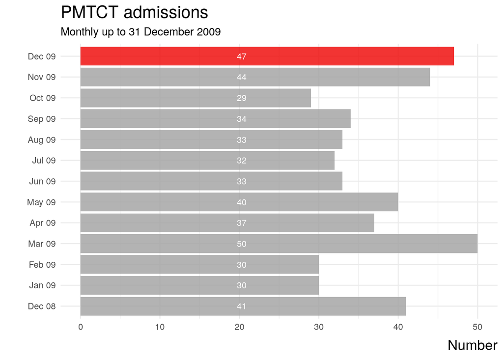

### Quarterly admissions

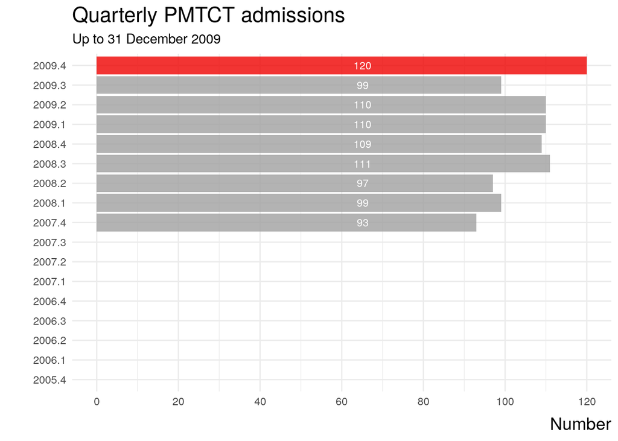

### Maternal age and gestation

|  | Reporting period N (%) | Reporting period Total | Previous 12 months N (%) | Previous 12 months Total | Full programme N (%) | Full programme Total |
| --- | --- | --- | --- | --- | --- | --- |
| Age: |  | 439 |  | 440 |  | 948 |
| 10-19y | 45 (10.3%) |  | 45 (10.2%) |  | 111 (11.7%) |  |
| 20-29y | 136 (31.0%) |  | 136 (30.9%) |  | 280 (29.5%) |  |
| 30-39y | 115 (26.2%) |  | 115 (26.1%) |  | 248 (26.2%) |  |
| 40-49y | 117 (26.7%) |  | 118 (26.8%) |  | 263 (27.7%) |  |
| 50-59y | 26 (5.9%) |  | 26 (5.9%) |  | 46 (4.9%) |  |
| 'Missing' | 0 (0.0%) |  | 0 (0.0%) |  | 0 (0.0%) |  |
| Gestation: |  | 439 |  | 440 |  | 948 |
| First trimester | 0 (0.0%) |  | 0 (0.0%) |  | 108 (11.4%) |  |
| Second trimester | 0 (0.0%) |  | 0 (0.0%) |  | 107 (11.3%) |  |
| Third trimester | 12 (2.7%) |  | 12 (2.7%) |  | 108 (11.4%) |  |
| Post-partum | 427 (97.3%) |  | 428 (97.3%) |  | 485 (51.2%) |  |
| 'Missing' | 0 (0.0%) |  | 0 (0.0%) |  | 140 (14.8%) |  |

### Definitions

The information in this section aims to summarise programme entry over time. This may be presented by treatment initiation or first consultation. Counts are split into calendar months or quarters and are tabulated and graphically represented. For comparison with more recent information, tables summarising monthly inclusions over the life of a programme are included.

Definition

**Table**  
Summarises the number and percentage of patients included in the cohort by calendar month. Episodes (e.g. treatment initation or pregnancy), rather than individual patients, are counted in this table.

**Monthly & Quarterly plots**  
Monthly and quarterly bar plots visually display programme entry by time period. These counts may be segregated further in some reports (e.g. TB treatment type). This type of plot should quickly illustrate seasonal or temporal changes in programme inclusion

**Maternal age and gestation**  
Programme entry has been stratified into maternal age categories and trimester at first consultation. Tremesters have been defined as 0-12 weeks, 13-27 weeks and 28-40 weeks. Gestation is presented as <i>post-partum</i> after 40 weeks. Gestation at admission to the PMTCT programme is calculated from the PMTCT admission date and the date of delivery. Gestation is recorded as missing where one of these dates is not entered. Three reporting periods have been included - the reporting period defined by the user, the 12 months prior to the end of the user-defined reporting period, and the full programme duration.

**Key variables**

> Admission cohort inclusion: Date of PMTCT admission  
> Delivery cohort inclusion: Date of delivery

**Key data form**

> 5_pregnancy_incl_pmtct_grossesse_incluant_ptme

## Deliveries

### Table

|  | Previous 13 months up to 31 December 2009 N (%) | Previous 13 months up to 31 December 2009 Total |
| --- | --- | --- |
| Month: |  | 433 |
| Dec-09 | 26 (6.0%) |  |
| Nov-09 | 29 (6.7%) |  |
| Oct-09 | 36 (8.3%) |  |
| Sep-09 | 36 (8.3%) |  |
| Aug-09 | 37 (8.5%) |  |
| Jul-09 | 32 (7.4%) |  |
| Jun-09 | 31 (7.2%) |  |
| May-09 | 38 (8.8%) |  |
| Apr-09 | 28 (6.5%) |  |
| Mar-09 | 39 (9.0%) |  |
| Feb-09 | 28 (6.5%) |  |
| Jan-09 | 35 (8.1%) |  |
| Dec-08 | 38 (8.8%) |  |

|  | Full programme inclusion up to 31 December 2009 N (%) | Full programme inclusion up to 31 December 2009 Total |
| --- | --- | --- |
| Month: |  | 827 |
| Dec | 87 (10.5%) |  |
| Nov | 71 (8.6%) |  |
| Oct | 67 (8.1%) |  |
| Sep | 65 (7.9%) |  |
| Aug | 73 (8.8%) |  |
| Jul | 64 (7.7%) |  |
| Jun | 67 (8.1%) |  |
| May | 69 (8.3%) |  |
| Apr | 67 (8.1%) |  |
| Mar | 69 (8.3%) |  |
| Feb | 57 (6.9%) |  |
| Jan | 71 (8.6%) |  |

### Monthly deliveries

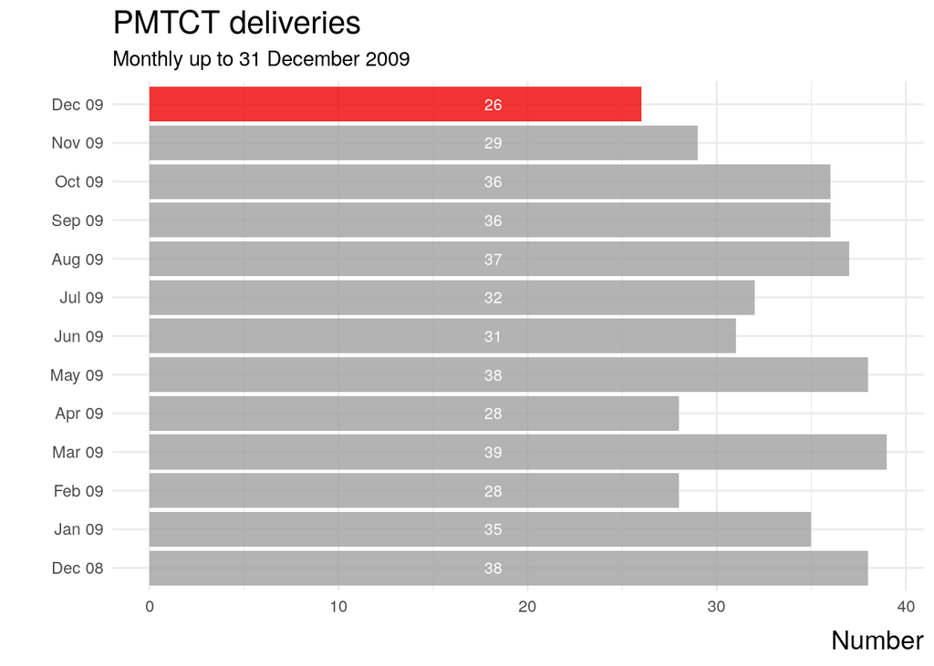

### Quarterly deliveries

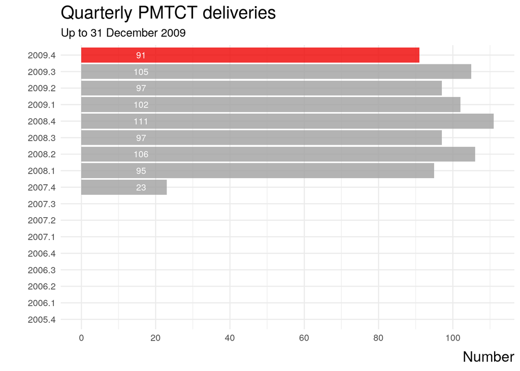

### Deliveries

|  | Reporting period N (%) | Reporting period Total | Previous 12 months N (%) | Previous 12 months Total | Full programme N (%) | Full programme Total |
| --- | --- | --- | --- | --- | --- | --- |
| Delivery Type: |  | 325 |  | 325 |  | 668 |
| Health Centre | 93 (28.6%) |  | 93 (28.6%) |  | 185 (27.7%) |  |
| Home | 77 (23.7%) |  | 77 (23.7%) |  | 168 (25.1%) |  |
| Hospital | 80 (24.6%) |  | 80 (24.6%) |  | 162 (24.3%) |  |
| Not specified | 75 (23.1%) |  | 75 (23.1%) |  | 153 (22.9%) |  |
| Live births: |  | 395 |  | 396 |  | 827 |
| 0 | 87 (22.0%) |  | 87 (22.0%) |  | 195 (23.6%) |  |
| 1 | 109 (27.6%) |  | 109 (27.5%) |  | 220 (26.6%) |  |
| 2 | 104 (26.3%) |  | 105 (26.5%) |  | 216 (26.1%) |  |
| 3 | 95 (24.1%) |  | 95 (24.0%) |  | 196 (23.7%) |  |

### Infants

|  | Reporting period N (%) | Reporting period Total | Previous 12 months N (%) | Previous 12 months Total | Full programme N (%) | Full programme Total |
| --- | --- | --- | --- | --- | --- | --- |
| HIV prophylaxis: |  | 395 |  | 396 |  | 827 |
| low risk NVP 6wks | 196 (49.6%) |  | 197 (49.7%) |  | 419 (50.7%) |  |
| high risk AZT+NVP 12wks | 76 (19.2%) |  | 76 (19.2%) |  | 151 (18.3%) |  |
| high risk NVP 12wks | 90 (22.8%) |  | 90 (22.7%) |  | 176 (21.3%) |  |
| Other | 15 (3.8%) |  | 15 (3.8%) |  | 39 (4.7%) |  |
| 'Missing' | 18 (4.6%) |  | 18 (4.5%) |  | 42 (5.1%) |  |
| Breastfeeding: |  | 258 |  | 259 |  | 551 |
| No | 131 (50.8%) |  | 131 (50.6%) |  | 281 (51.0%) |  |
| Yes | 127 (49.2%) |  | 128 (49.4%) |  | 270 (49.0%) |  |

### Definitions

This section provides a summary of the number of deliveries within the programme, their outcomes and information about the infant's immediate HIV care.

Definition

**Deliveries**  
The number of deliveries within the programme are tabulated and plotted by month and quarter. Delivery type and the number of live births is recorded for each reporting period. Three reporting periods have been included - the reporting period defined by the user, the 12 months prior to the end of the user-defined reporting period, and the full programme duration..

**Infants**  
Where a live infant was born, HIV prophylaxis type and breastfeeding status are summarised.

**Key variables**

> Admission cohort inclusion: Date of PMTCT admission  
> Delivery cohort inclusion: Date of delivery

**Key data form**

> 5_pregnancy_incl_pmtct_grossesse_incluant_ptme

## Maternal HIV

### Treatment on admission

|  | Reporting period N (%) | Reporting period Total | Previous 12 months N (%) | Previous 12 months Total | Full programme N (%) | Full programme Total |
| --- | --- | --- | --- | --- | --- | --- |
| Admission ART regimen: |  | 439 |  | 440 |  | 948 |
| TDF/3TC/DTG | 0 (0.0%) |  | 0 (0.0%) |  | 0 (0.0%) |  |
| TDF/3TC/EFV | 0 (0.0%) |  | 0 (0.0%) |  | 0 (0.0%) |  |
| ABC/3TC/DTG | 0 (0.0%) |  | 0 (0.0%) |  | 0 (0.0%) |  |
| ABC/3TC/EFV | 0 (0.0%) |  | 0 (0.0%) |  | 0 (0.0%) |  |
| TDF/3TC/ATV/r | 0 (0.0%) |  | 0 (0.0%) |  | 0 (0.0%) |  |
| AZT/3TC/EFV | 0 (0.0%) |  | 0 (0.0%) |  | 0 (0.0%) |  |
| Other | 315 (71.8%) |  | 316 (71.8%) |  | 488 (51.5%) |  |
| No treatment | 23 (5.2%) |  | 23 (5.2%) |  | 36 (3.8%) |  |
| 'Missing' | 101 (23.0%) |  | 101 (23.0%) |  | 424 (44.7%) |  |

### Treatment at delivery

|  | Reporting period N (%) | Reporting period Total | Previous 12 months N (%) | Previous 12 months Total | Full programme N (%) | Full programme Total |
| --- | --- | --- | --- | --- | --- | --- |
| ART regimen at delivery: |  | 395 |  | 396 |  | 827 |
| TDF/3TC/DTG | 0 (0.0%) |  | 0 (0.0%) |  | 0 (0.0%) |  |
| TDF/3TC/EFV | 0 (0.0%) |  | 0 (0.0%) |  | 0 (0.0%) |  |
| ABC/3TC/DTG | 0 (0.0%) |  | 0 (0.0%) |  | 0 (0.0%) |  |
| ABC/3TC/EFV | 0 (0.0%) |  | 0 (0.0%) |  | 0 (0.0%) |  |
| TDF/3TC/ATV/r | 0 (0.0%) |  | 0 (0.0%) |  | 0 (0.0%) |  |
| AZT/3TC/EFV | 0 (0.0%) |  | 0 (0.0%) |  | 0 (0.0%) |  |
| Other | 328 (83.0%) |  | 329 (83.1%) |  | 700 (84.6%) |  |
| No treatment | 26 (6.6%) |  | 26 (6.6%) |  | 51 (6.2%) |  |
| 'Missing' | 41 (10.4%) |  | 41 (10.4%) |  | 76 (9.2%) |  |

# Programme results

Since specific durations of time must pass from delivery to achieving programme results, they are reported below for historic delivery-cohorts as labeled.

## EID results

### Table

|  | Delivery quarter Q2, 2009 N (%) | Delivery quarter Q2, 2009 N | Older programme outcomes N (%) | Older programme outcomes N |
| --- | --- | --- | --- | --- |
| EID performed: |  | 97 |  | 534 |
| No | 88 (90.7%) |  | 481 (90.1%) |  |
| Yes | 9 (9.3%) |  | 53 (9.9%) |  |
| 'Missing' | 0 (0.0%) |  | 0 (0.0%) |  |
| EID results: |  | 97 |  | 534 |
| HIV Negative | 1 (1.0%) |  | 12 (2.2%) |  |
| HIV Positive | 4 (4.1%) |  | 8 (1.5%) |  |
| 'Missing' | 92 (94.8%) |  | 514 (96.3%) |  |

### Plot

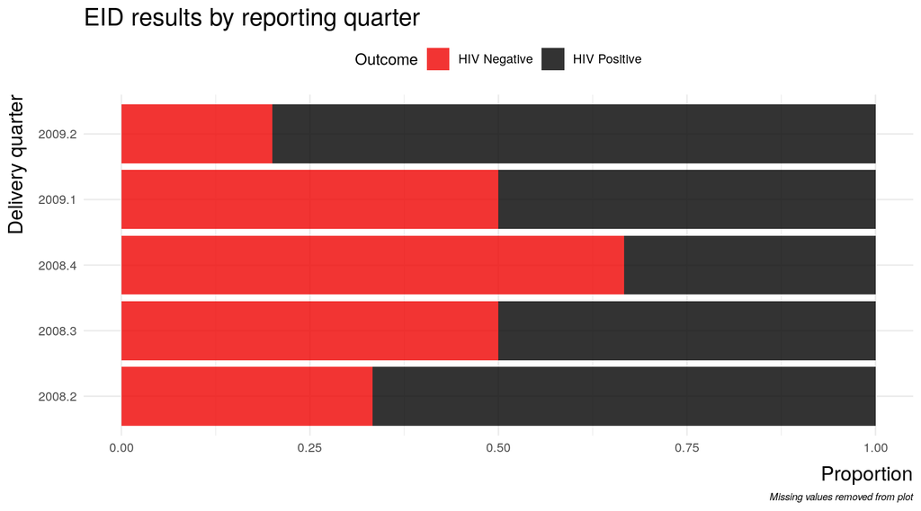

### Definitions

Early Infant Diagnosis should be performed before 12 weeks of life using an age-appropriate test.

Definition

**EID performed**  
This is a process indicator which establishes the proportion of all live births who were tested for HIV prior to 12 weeks of age. The indicator requires an HIV assessment date within 12 weeks of birth with a molecular HIV test type being recorded. A record of an HIV test result is not required for this indicator.

**EID results**  
This quality indicator describes the proportion of infants tested who had a positive result. Indeterminate, unknown or unavailable results are recorded as missing.

**Key data form**

> 5_pregnancy_incl_pmtct_grossesse_incluant_ptme_pmtct_infant_hiv

## Programme outcome

### Table

|  | Delivery quarter Q1, 2008 N (%) | Delivery quarter Q1, 2008 N | Older programme outcomes N (%) | Older programme outcomes N |
| --- | --- | --- | --- | --- |
| Infant final HIV status: |  | 93 |  | 23 |
| Negative | 60 (64.5%) |  | 18 (78.3%) |  |
| Positive | 33 (35.5%) |  | 5 (21.7%) |  |
| Final programme outcome: |  | 85 |  | 18 |
| Dead before final HIV status known | 12 (14.1%) |  | 7 (38.9%) |  |
| Follow-up complete final HIV status known | 14 (16.5%) |  | 4 (22.2%) |  |
| LTFU before final HIV status known | 25 (29.4%) |  | 2 (11.1%) |  |
| Other | 17 (20.0%) |  | 2 (11.1%) |  |
| Transferred before final HIV status known | 17 (20.0%) |  | 3 (16.7%) |  |

### HIV outcome by prophylaxis

|  | Delivery quarter Q1, 2008 Final HIV status Negative | Delivery quarter Q1, 2008 Final HIV status Positive | Older programme Final HIV status Negative | Older programme Final HIV status Positive |
| --- | --- | --- | --- | --- |
| Prophylaxis type: |  |  |  |  |
| low risk NVP 6wks | 29 (48.3%) | 21 (63.6%) | 8 (44.4%) | 1 (20.0%) |
| high risk AZT+NVP 12wks | 10 (16.7%) | 1 (3.0%) | 4 (22.2%) | 1 (20.0%) |
| high risk NVP 12wks | 12 (20.0%) | 5 (15.2%) | 6 (33.3%) | 2 (40.0%) |
| Other | 1 (1.7%) | 5 (15.2%) | 0 (0.0%) | 0 (0.0%) |
| 'Missing' | 8 (13.3%) | 1 (3.0%) | 0 (0.0%) | 1 (20.0%) |

### Definitions

The PMTCT programme outcome is given 18 months after delivery to allow sufficient time for infants to be tested for HIV using an antigen/antibody test. Infants may continue to be exposed to HIV through breastfeeding, but for convenience of reporting, outcomes are attributed 18 months after delivery.

Definition

**Final HIV status**  
The final HIV test result recorded for each infant

**Final programme outcome**  
The final programme outcome recorded for each infant.

**Key data form**

> 5_pregnancy_incl_pmtct_grossesse_incluant_ptme_pmtct_infant_hiv